# Takehome Final Exam

Kevin Russell

# Problem 1: [26 Points Total]

On HuskyCT, I have provided a file called fashion_final.csv. This file contains a subset of the “fashion MNIST” data. This dataset is composed of 1000 rows and 786 columns. Each row represents a different 28 by 28 pixel image of a garment.

The following is a brief description of the data:

The first column (picture_num) indexes the the photos from 1 to 1000. The second column (garment) is categorical, taking on 10 different values (0-9) to describe different classes of garment. The remaining columns all have names of the form x.._y.. describing the pixel intensity of the image at a particular location. For instance, x14_y14 describes the pixel intensity at the x=14 and y=14 coordinate, near the center of each image. Meanwhile, the x1_y28 variable describes the pixel intensity at the bottom right of each image.

Through the various parts of this problem, we read in, clean, manipulate, and plot this data. I have included reference datasets/images to compare against to check if you performed the steps correctly.

## Part A: Read and Clean the Data [4 Points]

Read in the data from fashion_final.csv. Change the garment variable from numeric to a factor. Relabel the factors according to the following levels.

- 0 T-shirt/top
- 1 Trouser
- 2 Pullover
- 3 Dress
- 4 Coat
- 5 Sandal
- 6 Shirt
- 7 Sneaker
- 8 Bag
- 9 Ankle boot

Once you have completed these steps, your new data frame should match the one provided on HuskyCT as “fashion_clean.Rda”. Recreate the following bar chart showing the number of each garment appearing in the dataset.

```r
library(tidyverse)
theme_set(theme_bw())
```

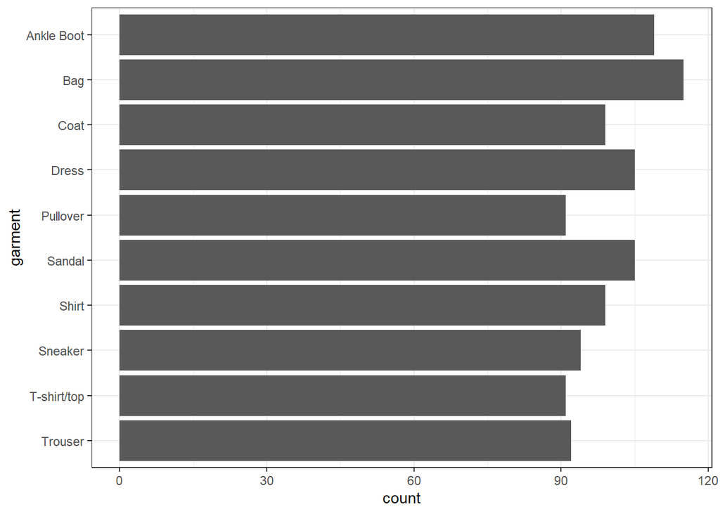

```r
fashion <- read.csv("fashion_final.csv")

fashion <- fashion |>
  mutate(garment = ifelse(garment == 0, "T-shirt/top", garment)) |>
  mutate(garment = ifelse(garment == 1, "Trouser", garment)) |>
  mutate(garment = ifelse(garment == 2, "Pullover", garment)) |>
  mutate(garment = ifelse(garment == 3, "Dress", garment)) |>
  mutate(garment = ifelse(garment == 4, "Coat", garment)) |>
  mutate(garment = ifelse(garment == 5, "Sandal", garment)) |>
  mutate(garment = ifelse(garment == 6, "Shirt", garment)) |>
  mutate(garment = ifelse(garment == 7, "Sneaker", garment)) |>
  mutate(garment = ifelse(garment == 8, "Bag", garment)) |>
  mutate(garment = ifelse(garment == 9, "Ankle Boot", garment)) |>
  mutate(garment = as.factor(garment))

library(ggplot2)

fashion |>
  group_by(garment) |>
  summarize(count = n()) |>
  ggplot(aes(x = count, y = reorder(garment, desc(garment)))) +
  geom_bar(stat = "identity") +
  labs(x = "count", y = "garment")
```

## Part B: Tidying the Data [8 Points]

Apply data manipulation techniques such that each row in the data frame corresponds to a single pixel of a single image. This new version of the data should have 784000 rows and five columns, occurring the following order:

- garment—a factor describing the type of garment (e.g. Trouser)
- picture_num—a number describing which photo the pixel is part of (spanning 1-1000)
- x—a number describing the horizontal coordinate of the pixel (spanning 1-28)
- y—a number describing the vertical coordinate of the pixel (spanning 1-28)
- value—a number describing the image’s pixel intensity at this pixel.

When completed, your new data frame should match the one provided on HuskyCT as “fashion_clean_longer.Rda”.

```r
fashion_clean_longer <- fashion |>
  pivot_longer(cols=starts_with("x"), names_to = "x", values_to = "value") |>
  mutate(x = parse_number(x),
         y = rep(rep(28:1, each = 28), 1000))
```

## Part C: Creating a Data frame of Example Images [4 Points]

Create a new data frame called fashion_examples. fashion_examples should be a subset of fashion_clean_longer containing the info for exactly one of each type of garment. Since there are ten types of garments and each image has 784 pixels, fashion_examples should contain exactly 7840 rows.

```r
fashion_1 <- fashion_clean_longer |>
  filter(garment == "T-shirt/top") |>
  head(784)

fashion_2 <- fashion_clean_longer |>
  filter(garment == "Trouser") |>
  head(784)

fashion_3 <- fashion_clean_longer |>
  filter(garment == "Pullover") |>
  head(784)

fashion_4 <- fashion_clean_longer |>
  filter(garment == "Dress") |>
  head(784)

fashion_5 <- fashion_clean_longer |>
  filter(garment == "Coat") |>
  head(784)

fashion_6 <- fashion_clean_longer |>
  filter(garment == "Sandal") |>
  head(784)

fashion_7 <- fashion_clean_longer |>
  filter(garment == "Shirt") |>
  head(784)

fashion_8 <- fashion_clean_longer |>
  filter(garment == "Sneaker") |>
  head(784)

fashion_9 <- fashion_clean_longer |>
  filter(garment == "Bag") |>
  head(784)

fashion_10 <- fashion_clean_longer |>
  filter(garment == "Ankle Boot") |>
  head(784)

fashion_examples = rbind(fashion_1, fashion_2, fashion_3, fashion_4, fashion_5, fashion_6, fashion_7, fashion_8, fashion_9, fashion_10)
```

Note: There are many possible correct responses to this question. It depends on which examples you pick.

## Part D: Plotting Example Images [4 Points]

Use geom_raster to make a faceted plot like one below showing one of each kind of garment. Note—your graphic doesn’t have to exactly match the one shown below. It depends on which example garments you picked.

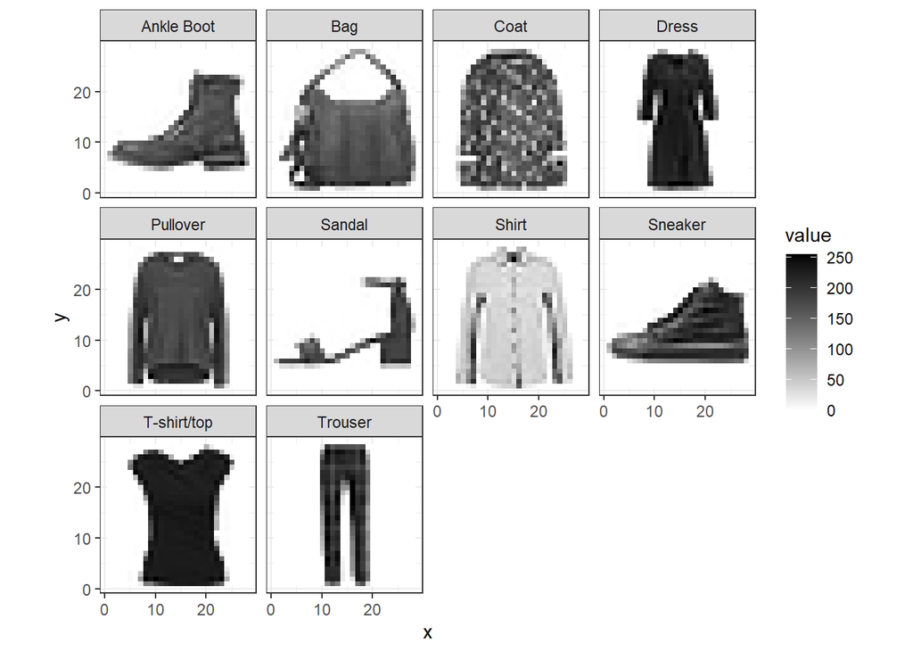

```r
fashion_examples |>
  ggplot(aes(x = x,
             y = y,
             fill = value)) +
  geom_raster() +
  scale_fill_gradient(low = "white",
                      high = "black")  +
  coord_fixed() +
  facet_wrap(~ garment)
```

## Part E: Computing the Average Garments [4 Points]

Use the dataset fashion_clean_longer (created in part B) to create a data frame showing the average value across the data for each pixel coordinate and each type of garment. Give this data frame the name fashion_average. It should match the data frame provided in “fashion_average.Rda”.

```r
fashion_average <- fashion_clean_longer |>
  group_by(garment, x, y) |>
  summarise(value = mean(value))
```

Which type of garment has the highest average pixel intensity at coordinate x = 10, y = 10?

```r
fashion_average |>
  filter(x == 10, y == 10) |>
  arrange(desc(value)) |>
  head(1)
```

```
## # A tibble: 1 × 4
## # Groups:   garment, x [1]
##   garment     x     y value
##   <fct>   <dbl> <int> <dbl>
## 1 Coat       10    10  173.
```

Coat.

## Part F: Plot the Averages [2 Points]

Use geom_raster to make a faceted plot like the one below showing the average pixel intensities for each type of garment.

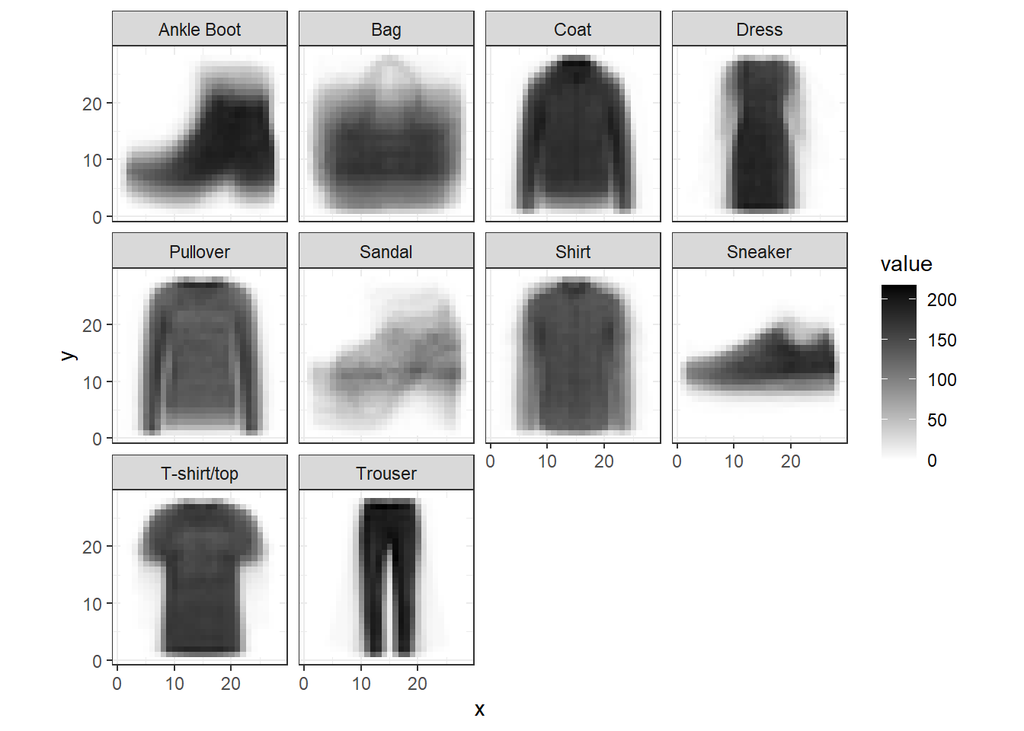

```r
fashion_average |>
  ggplot(aes(x = x,
             y = y,
             fill = value)) +
  geom_raster() +
  scale_fill_gradient(low = "white",
                      high = "black")  +
  coord_fixed()+
  facet_wrap(~ garment)
```

# Problem 2: [42 Points Total]

On HuskyCT, I have provided two files related to books.

- book_names.csv contains the title and goodreads book id for 10,000 popular books.
- book_ratings.csv contains the average good reads ratings and original publication year for each of these 10,000 books, along with their goodreads book id and the code for the language of the book.

In this question, we will be reading in, merging, and analyzing this dataset.

## Part A: Read and Merge Data [6 points]

Read in both book_names.csv and book_ratings.csv. Merge the two datasets based on the goodreads book id to create a single data frame showing book title, original publication year, average rating for each book, and language_code. Remove any entries with missing book names.

Also remove any books with titles in which the first character is not one of A-Z, a-z, or 0-9. Convert language_code into a factor.

```r
names <- read.csv("book_names.csv")
ratings <- read.csv("book_ratings.csv")

books <- names |>
  mutate(book_id = goodreads_book_id) |>
  dplyr::select(book_title, book_id) |>
  inner_join(ratings, by= "book_id") |>
  drop_na("book_title") |>
  filter(grepl("^[A-Za-z0-9]", book_title)) |>
  dplyr::select(book_title, language_code, original_publication_year, average_rating) |>
  mutate(language_code = as.factor(language_code))
```

The result should have 9138 rows and 4 columns, matching the data frame provided in books.Rda on HuskyCT.